# FM-1.7.0：Top1概率与实际命中率

本报告仅描述26098、26101、26102三期冻结预测，回答高Top1概率是否对应高命中，以及预测概率是否校准。不估计新参数、不按赛果选择下注阈值、不改FM来源路由、尾部政策或预测。目标赛果已知，不能当作独立前瞻证据。

**当前样本未支持“FM Top1概率越大，越容易命中”。** 总体平均预测45.8%，实际38.0%；来源分层显示原生过度自信明显，市场来源整体接近校准，但高概率组不足。结论限于这三期，不说明长期一定无效，也不支持反向下注。

```r
suppressPackageStartupMessages(library(tidyverse))
root <- normalizePath(params$repository_root, mustWork = TRUE)
out <- file.path(root, params$output_directory)
dir.create(out, recursive = TRUE, showWarnings = FALSE)
log <- file.path(out, "qmd-execution.log")
status <- system2("/opt/R/4.6.1/bin/Rscript", shQuote(c(
  file.path(root, "r/fm17_top1_calibration.R"), root, out)),
  env = paste0("R_LIBS=", shQuote(paste(.libPaths(), collapse = ":"))), stdout = log, stderr = log)
if (status != 0L) stop(paste(readLines(log), collapse = "\n"))
receipt <- jsonlite::fromJSON(file.path(out, "receipt.json"))
stopifnot(length(names(receipt$output_hashes)) == 3L)
for (name in names(receipt$output_hashes)) stopifnot(
  digest::digest(file = file.path(out, paste0(name, ".csv")), algo = "sha256") == receipt$output_hashes[[name]])
bins <- read_csv(file.path(out, "bins.csv"), show_col_types = FALSE)
summary <- read_csv(file.path(out, "summary.csv"), show_col_types = FALSE)
fixtures <- read_csv(file.path(out, "fixtures.csv"), show_col_types = FALSE)
```

## 数据、分箱与分析合同

原FM17冻结共346场，完整名单347场：26098#135无截止无预测、#102取消不评分，最终345场。较晚赛前SP共同样本345场；同T−24h SP共同样本214场。北单概率为SP倒数归一化，不使用结算SP。北单按自己的Top1概率分箱，各模型同箱的场次不一定相同；总体比较使用相同场次。来源分层始终指FM冻结来源，不表示北单也有原生／市场路由。

预设分箱为[1/3,40%)、[40%,50%)、[50%,60%)、[60%,70%)、[70%,80%)、[80%,90%)、[90%,100%]，左闭右开且最后包括100%，没有为改善结果重新合箱。空箱保留n=0、均值NA。此处“Top1概率”是三分类最大概率，**不是定性基本面置信分数**。

数据键：fixture_id/model/outcome为概率唯一键，每组W/D/L三行且和为1；labels以fixture_id唯一。同模型、时点、分层中的每场仅计一次；分层分别展示，不能重复累加。输出fixtures每行是一场／模型／比较时点，bins每行是分层／模型／分箱，summary每行是分层／模型。概率double、命中logical、计数integer，标识符character，截止随原输入保留ISO UTC文本；R中SP时钟显式转为POSIXct UTC比较。空／缺失／非法概率、重复或不完整键失败。

原预测RDS、赛果、SP和来源／赛事分类coverage均核验既有SHA256。跨期冻结时点不变，不重放任何新的学习／策略决策函数。可复用内部函数`Top1Reliability()`调用已安装包的`DcAccuracyDiagnostic()`验证概率合同并沿用W,D,L并列排序；返回描述性分箱、总体和逐场表，无估计变换或阈值优化。收据记录实际评分函数体哈希、实现哈希、输入输出哈希与学习库存；没有复用跨截止模型缓存。原始历史页面及时间代理的事后诊断限制不变。

## 总体分箱与校准

区分能力看高概率组是否命中更多；校准看实际命中率是否接近组内平均预测概率。校准差=实际−预测，负数表示过度自信。相关系数是逐场最大概率与Top1命中0/1的Pearson描述性相关，不做显著性检验；退化组输出NA。

```r
knitr::kable(bins |> filter(comparison == "near_sale", dimension == "all", model == "FM-1.7.0") |>
  select(lower, upper, n, hits1, mean_p1, hit_rate, calibration_gap, mean_p12, top2_rate, rank2_rate, rank3_rate),
  digits = 4, caption = "345场原FM17：Top1分箱及同箱Top2／排名分布；均为比例0—1")
```

345场原FM17：Top1分箱及同箱Top2／排名分布；均为比例0—1

| lower | upper | n | hits1 | mean_p1 | hit_rate | calibration_gap | mean_p12 | top2_rate | rank2_rate | rank3_rate |
| --- | --- | --- | --- | --- | --- | --- | --- | --- | --- | --- |
| 0.3333 | 0.4 | 83 | 30 | 0.3769 | 0.3614 | -0.0155 | 0.7172 | 0.7349 | 0.3735 | 0.2651 |
| 0.4000 | 0.5 | 186 | 75 | 0.4467 | 0.4032 | -0.0435 | 0.7497 | 0.7419 | 0.3387 | 0.2581 |
| 0.5000 | 0.6 | 54 | 19 | 0.5262 | 0.3519 | -0.1744 | 0.7849 | 0.5926 | 0.2407 | 0.4074 |
| 0.6000 | 0.7 | 14 | 4 | 0.6407 | 0.2857 | -0.3550 | 0.8453 | 0.7857 | 0.5000 | 0.2143 |
| 0.7000 | 0.8 | 6 | 2 | 0.7448 | 0.3333 | -0.4115 | 0.8959 | 1.0000 | 0.6667 | 0.0000 |
| 0.8000 | 0.9 | 2 | 1 | 0.8383 | 0.5000 | -0.3383 | 0.9542 | 1.0000 | 0.5000 | 0.0000 |
| 0.9000 | 1.0 | 0 | 0 | NA | NA | NA | NA | NA | NA | NA |

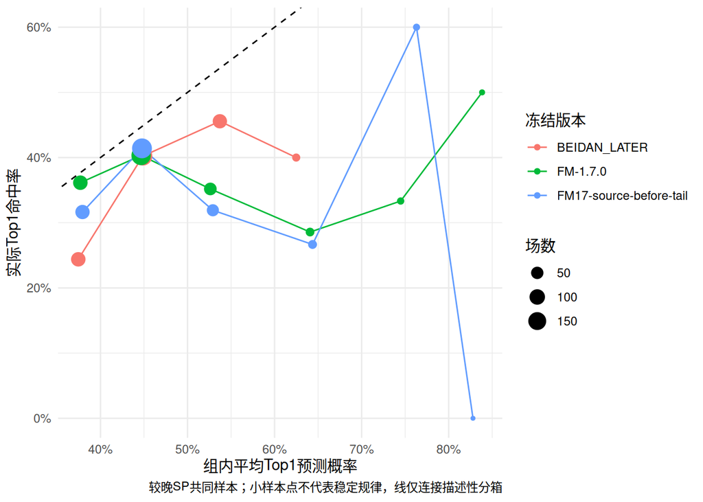

```r
bins |> filter(comparison == "near_sale", dimension == "all", n > 0) |>
  ggplot(aes(mean_p1, hit_rate, colour = model)) + geom_abline(slope = 1, intercept = 0, linetype = 2) +
  geom_line() + geom_point(aes(size = n)) +
  scale_x_continuous(labels = scales::percent) + scale_y_continuous(labels = scales::percent) +
  labs(x = "组内平均Top1预测概率", y = "实际Top1命中率", size = "场数", colour = "冻结版本",
    caption = "较晚SP共同样本；小样本点不代表稳定规律，线仅连接描述性分箱") + theme_minimal()
```

```r
knitr::kable(summary |> filter(comparison == "near_sale", dimension == "all"), digits = 5,
  caption = "整体与尾部前对照；相关不是因果或显著性结论")
```

整体与尾部前对照；相关不是因果或显著性结论

| comparison | dimension | stratum | model | n | hits1 | hits2 | mean_p1 | hit_rate | mean_p12 | top2_rate | calibration_gap | hit_confidence | miss_confidence | confidence_hit_correlation |
| --- | --- | --- | --- | --- | --- | --- | --- | --- | --- | --- | --- | --- | --- | --- |
| near_sale | all | ALL | BEIDAN_LATER | 345 | 130 | 244 | 0.45643 | 0.37681 | 0.75885 | 0.70725 | -0.07962 | 0.46621 | 0.45051 | 0.11126 |
| near_sale | all | ALL | FM-1.7.0 | 345 | 131 | 250 | 0.45769 | 0.37971 | 0.75498 | 0.72464 | -0.07798 | 0.45573 | 0.45889 | -0.01885 |
| near_sale | all | ALL | FM17-source-before-tail | 345 | 129 | 244 | 0.45732 | 0.37391 | 0.75965 | 0.70725 | -0.08341 | 0.45733 | 0.45732 | 0.00010 |

FM 40%—50%组186场命中75场（40.3%）；50%—60%组54场命中19场（35.2%），60%—70%组14场命中4场（28.6%）。70%以上总计仅8场，不能声称更高概率必然更差。90%以上为空箱。

整体预测45.77%、命中37.97%，高估7.80个百分点；命中场的平均预测45.56%左右，未中场约45.90%，相关约−0.019。尾部前相关约0.0001，说明本样本区分能力不足不是仅由尾部产生。较晚北单总体同样偏高（45.64%预测、37.68%实际），但相关约+0.111；该弱正相关不能当显著稳定优势。

## 逐期、来源与赛事类型

```r
knitr::kable(summary |> filter(comparison == "near_sale", dimension == "issue"), digits = 5,
  caption = "逐期平均预测、命中及相关；三期不能视作大量独立窗口")
```

逐期平均预测、命中及相关；三期不能视作大量独立窗口

| comparison | dimension | stratum | model | n | hits1 | hits2 | mean_p1 | hit_rate | mean_p12 | top2_rate | calibration_gap | hit_confidence | miss_confidence | confidence_hit_correlation |
| --- | --- | --- | --- | --- | --- | --- | --- | --- | --- | --- | --- | --- | --- | --- |
| near_sale | issue | 26098 | BEIDAN_LATER | 144 | 57 | 105 | 0.45420 | 0.39583 | 0.75658 | 0.72917 | -0.05837 | 0.45899 | 0.45107 | 0.06358 |
| near_sale | issue | 26098 | FM-1.7.0 | 144 | 56 | 102 | 0.44377 | 0.38889 | 0.74809 | 0.70833 | -0.05488 | 0.45475 | 0.43678 | 0.12644 |
| near_sale | issue | 26098 | FM17-source-before-tail | 144 | 55 | 97 | 0.44349 | 0.38194 | 0.75526 | 0.67361 | -0.06155 | 0.45541 | 0.43612 | 0.13826 |
| near_sale | issue | 26101 | BEIDAN_LATER | 115 | 37 | 71 | 0.46039 | 0.32174 | 0.76232 | 0.61739 | -0.13865 | 0.47345 | 0.45419 | 0.11634 |
| near_sale | issue | 26101 | FM-1.7.0 | 115 | 42 | 83 | 0.46930 | 0.36522 | 0.75966 | 0.72174 | -0.10408 | 0.43856 | 0.48698 | -0.24120 |
| near_sale | issue | 26101 | FM17-source-before-tail | 115 | 42 | 82 | 0.46844 | 0.36522 | 0.76120 | 0.71304 | -0.10322 | 0.43966 | 0.48500 | -0.23982 |
| near_sale | issue | 26102 | BEIDAN_LATER | 86 | 36 | 68 | 0.45486 | 0.41860 | 0.75803 | 0.79070 | -0.03625 | 0.47019 | 0.44382 | 0.19413 |
| near_sale | issue | 26102 | FM-1.7.0 | 86 | 33 | 65 | 0.46548 | 0.38372 | 0.76024 | 0.75581 | -0.08176 | 0.47925 | 0.45690 | 0.14728 |
| near_sale | issue | 26102 | FM17-source-before-tail | 86 | 32 | 65 | 0.46562 | 0.37209 | 0.76493 | 0.75581 | -0.09353 | 0.48384 | 0.45483 | 0.19954 |

```r
knitr::kable(bins |> filter(comparison == "near_sale", dimension == "issue", model == "FM-1.7.0"), digits = 4,
  caption = "原FM逐期分箱，包含空箱；用于观察总体是否掩盖期差异")
```

原FM逐期分箱，包含空箱；用于观察总体是否掩盖期差异

| comparison | dimension | stratum | model | bin | n | hits1 | hits2 | mean_p1 | hit_rate | mean_p12 | top2_rate | rank2_rate | rank3_rate | lower | upper | calibration_gap | top2_calibration_gap |
| --- | --- | --- | --- | --- | --- | --- | --- | --- | --- | --- | --- | --- | --- | --- | --- | --- | --- |
| near_sale | issue | 26098 | FM-1.7.0 | 1 | 44 | 13 | 32 | 0.3801 | 0.2955 | 0.7208 | 0.7273 | 0.4318 | 0.2727 | 0.3333 | 0.4 | -0.0847 | 0.0064 |
| near_sale | issue | 26098 | FM-1.7.0 | 2 | 80 | 33 | 56 | 0.4489 | 0.4125 | 0.7493 | 0.7000 | 0.2875 | 0.3000 | 0.4000 | 0.5 | -0.0364 | -0.0493 |
| near_sale | issue | 26098 | FM-1.7.0 | 3 | 16 | 8 | 11 | 0.5219 | 0.5000 | 0.7841 | 0.6875 | 0.1875 | 0.3125 | 0.5000 | 0.6 | -0.0219 | -0.0966 |
| near_sale | issue | 26098 | FM-1.7.0 | 4 | 1 | 0 | 0 | 0.6162 | 0.0000 | 0.8272 | 0.0000 | 0.0000 | 1.0000 | 0.6000 | 0.7 | -0.6162 | -0.8272 |
| near_sale | issue | 26098 | FM-1.7.0 | 5 | 3 | 2 | 3 | 0.7649 | 0.6667 | 0.8974 | 1.0000 | 0.3333 | 0.0000 | 0.7000 | 0.8 | -0.0982 | 0.1026 |
| near_sale | issue | 26098 | FM-1.7.0 | 6 | 0 | 0 | 0 | NA | NA | NA | NA | NA | NA | 0.8000 | 0.9 | NA | NA |
| near_sale | issue | 26098 | FM-1.7.0 | 7 | 0 | 0 | 0 | NA | NA | NA | NA | NA | NA | 0.9000 | 1.0 | NA | NA |
| near_sale | issue | 26101 | FM-1.7.0 | 1 | 25 | 11 | 18 | 0.3704 | 0.4400 | 0.7098 | 0.7200 | 0.2800 | 0.2800 | 0.3333 | 0.4 | 0.0696 | 0.0102 |
| near_sale | issue | 26101 | FM-1.7.0 | 2 | 55 | 25 | 43 | 0.4405 | 0.4545 | 0.7453 | 0.7818 | 0.3273 | 0.2182 | 0.4000 | 0.5 | 0.0141 | 0.0365 |
| near_sale | issue | 26101 | FM-1.7.0 | 3 | 22 | 5 | 11 | 0.5285 | 0.2273 | 0.7863 | 0.5000 | 0.2727 | 0.5000 | 0.5000 | 0.6 | -0.3012 | -0.2863 |
| near_sale | issue | 26101 | FM-1.7.0 | 4 | 9 | 1 | 7 | 0.6462 | 0.1111 | 0.8518 | 0.7778 | 0.6667 | 0.2222 | 0.6000 | 0.7 | -0.5351 | -0.0740 |
| near_sale | issue | 26101 | FM-1.7.0 | 5 | 3 | 0 | 3 | 0.7247 | 0.0000 | 0.8943 | 1.0000 | 1.0000 | 0.0000 | 0.7000 | 0.8 | -0.7247 | 0.1057 |
| near_sale | issue | 26101 | FM-1.7.0 | 6 | 1 | 0 | 1 | 0.8657 | 0.0000 | 0.9784 | 1.0000 | 1.0000 | 0.0000 | 0.8000 | 0.9 | -0.8657 | 0.0216 |
| near_sale | issue | 26101 | FM-1.7.0 | 7 | 0 | 0 | 0 | NA | NA | NA | NA | NA | NA | 0.9000 | 1.0 | NA | NA |
| near_sale | issue | 26102 | FM-1.7.0 | 1 | 14 | 6 | 11 | 0.3783 | 0.4286 | 0.7190 | 0.7857 | 0.3571 | 0.2143 | 0.3333 | 0.4 | 0.0503 | 0.0667 |
| near_sale | issue | 26102 | FM-1.7.0 | 2 | 51 | 17 | 39 | 0.4500 | 0.3333 | 0.7549 | 0.7647 | 0.4314 | 0.2353 | 0.4000 | 0.5 | -0.1166 | 0.0098 |
| near_sale | issue | 26102 | FM-1.7.0 | 3 | 16 | 6 | 10 | 0.5273 | 0.3750 | 0.7840 | 0.6250 | 0.2500 | 0.3750 | 0.5000 | 0.6 | -0.1523 | -0.1590 |
| near_sale | issue | 26102 | FM-1.7.0 | 4 | 4 | 3 | 4 | 0.6346 | 0.7500 | 0.8352 | 1.0000 | 0.2500 | 0.0000 | 0.6000 | 0.7 | 0.1154 | 0.1648 |
| near_sale | issue | 26102 | FM-1.7.0 | 5 | 0 | 0 | 0 | NA | NA | NA | NA | NA | NA | 0.7000 | 0.8 | NA | NA |
| near_sale | issue | 26102 | FM-1.7.0 | 6 | 1 | 1 | 1 | 0.8110 | 1.0000 | 0.9300 | 1.0000 | 0.0000 | 0.0000 | 0.8000 | 0.9 | 0.1890 | 0.0700 |
| near_sale | issue | 26102 | FM-1.7.0 | 7 | 0 | 0 | 0 | NA | NA | NA | NA | NA | NA | 0.9000 | 1.0 | NA | NA |

```r
knitr::kable(summary |> filter(comparison == "near_sale", dimension %in% c("source", "event_type")), digits = 5,
  caption = "来源与赛事类型分别分层；不解释为替换来源的因果效应")
```

来源与赛事类型分别分层；不解释为替换来源的因果效应

| comparison | dimension | stratum | model | n | hits1 | hits2 | mean_p1 | hit_rate | mean_p12 | top2_rate | calibration_gap | hit_confidence | miss_confidence | confidence_hit_correlation |
| --- | --- | --- | --- | --- | --- | --- | --- | --- | --- | --- | --- | --- | --- | --- |
| near_sale | source | market | BEIDAN_LATER | 228 | 88 | 165 | 0.46216 | 0.38596 | 0.76163 | 0.72368 | -0.07619 | 0.47709 | 0.45277 | 0.16752 |
| near_sale | source | market | FM-1.7.0 | 228 | 98 | 165 | 0.44201 | 0.42982 | 0.74852 | 0.72368 | -0.01219 | 0.44562 | 0.43929 | 0.06151 |
| near_sale | source | market | FM17-source-before-tail | 228 | 95 | 158 | 0.44224 | 0.41667 | 0.75558 | 0.69298 | -0.02557 | 0.44852 | 0.43775 | 0.10932 |
| near_sale | source | native | BEIDAN_LATER | 117 | 42 | 79 | 0.44525 | 0.35897 | 0.75344 | 0.67521 | -0.08628 | 0.44340 | 0.44630 | -0.02241 |
| near_sale | source | native | FM-1.7.0 | 117 | 33 | 85 | 0.48824 | 0.28205 | 0.76756 | 0.72650 | -0.20619 | 0.48577 | 0.48922 | -0.01359 |
| near_sale | source | native | FM17-source-before-tail | 117 | 34 | 86 | 0.48672 | 0.29060 | 0.76759 | 0.73504 | -0.19612 | 0.48195 | 0.48867 | -0.02793 |
| near_sale | event_type | youth | BEIDAN_LATER | 43 | 19 | 36 | 0.47135 | 0.44186 | 0.76614 | 0.83721 | -0.02949 | 0.47262 | 0.47035 | 0.01736 |
| near_sale | event_type | youth | FM-1.7.0 | 43 | 21 | 38 | 0.47167 | 0.48837 | 0.76453 | 0.88372 | 0.01670 | 0.48711 | 0.45693 | 0.19246 |
| near_sale | event_type | youth | FM17-source-before-tail | 43 | 20 | 39 | 0.47044 | 0.46512 | 0.77327 | 0.90698 | -0.00533 | 0.49255 | 0.45122 | 0.27239 |
| near_sale | event_type | national | BEIDAN_LATER | 84 | 30 | 56 | 0.45048 | 0.35714 | 0.75941 | 0.66667 | -0.09333 | 0.46688 | 0.44136 | 0.16736 |
| near_sale | event_type | national | FM-1.7.0 | 84 | 34 | 57 | 0.45255 | 0.40476 | 0.75522 | 0.67857 | -0.04779 | 0.45194 | 0.45297 | -0.00622 |
| near_sale | event_type | national | FM17-source-before-tail | 84 | 31 | 53 | 0.45398 | 0.36905 | 0.76154 | 0.63095 | -0.08493 | 0.46077 | 0.45000 | 0.06697 |
| near_sale | event_type | league | BEIDAN_LATER | 193 | 75 | 138 | 0.45641 | 0.38860 | 0.75647 | 0.71503 | -0.06780 | 0.46457 | 0.45122 | 0.09757 |
| near_sale | event_type | league | FM-1.7.0 | 193 | 70 | 134 | 0.45126 | 0.36269 | 0.74992 | 0.69430 | -0.08856 | 0.45045 | 0.45172 | -0.00838 |
| near_sale | event_type | league | FM17-source-before-tail | 193 | 72 | 131 | 0.45086 | 0.37306 | 0.75367 | 0.67876 | -0.07781 | 0.44867 | 0.45217 | -0.02422 |
| near_sale | event_type | cup | BEIDAN_LATER | 25 | 6 | 14 | 0.45091 | 0.24000 | 0.76285 | 0.56000 | -0.21091 | 0.46297 | 0.44710 | 0.10243 |
| near_sale | event_type | cup | FM-1.7.0 | 25 | 6 | 21 | 0.50057 | 0.24000 | 0.77674 | 0.84000 | -0.26057 | 0.42896 | 0.52319 | -0.32513 |
| near_sale | event_type | cup | FM17-source-before-tail | 25 | 6 | 21 | 0.49589 | 0.24000 | 0.77605 | 0.84000 | -0.25589 | 0.42615 | 0.51791 | -0.33508 |

```r
knitr::kable(bins |> filter(comparison == "near_sale", dimension %in% c("source", "event_type"), model == "FM-1.7.0"), digits = 4,
  caption = "原FM按来源／类型的全部固定分箱；稀疏保留，不根据命中重设边界")
```

原FM按来源／类型的全部固定分箱；稀疏保留，不根据命中重设边界

| comparison | dimension | stratum | model | bin | n | hits1 | hits2 | mean_p1 | hit_rate | mean_p12 | top2_rate | rank2_rate | rank3_rate | lower | upper | calibration_gap | top2_calibration_gap |
| --- | --- | --- | --- | --- | --- | --- | --- | --- | --- | --- | --- | --- | --- | --- | --- | --- | --- |
| near_sale | source | market | FM-1.7.0 | 1 | 53 | 19 | 38 | 0.3761 | 0.3585 | 0.7201 | 0.7170 | 0.3585 | 0.2830 | 0.3333 | 0.4 | -0.0176 | -0.0031 |
| near_sale | source | market | FM-1.7.0 | 2 | 141 | 64 | 107 | 0.4476 | 0.4539 | 0.7504 | 0.7589 | 0.3050 | 0.2411 | 0.4000 | 0.5 | 0.0063 | 0.0085 |
| near_sale | source | market | FM-1.7.0 | 3 | 33 | 14 | 19 | 0.5189 | 0.4242 | 0.7841 | 0.5758 | 0.1515 | 0.4242 | 0.5000 | 0.6 | -0.0947 | -0.2084 |
| near_sale | source | market | FM-1.7.0 | 4 | 1 | 1 | 1 | 0.6162 | 1.0000 | 0.8212 | 1.0000 | 0.0000 | 0.0000 | 0.6000 | 0.7 | 0.3838 | 0.1788 |
| near_sale | source | market | FM-1.7.0 | 5 | 0 | 0 | 0 | NA | NA | NA | NA | NA | NA | 0.7000 | 0.8 | NA | NA |
| near_sale | source | market | FM-1.7.0 | 6 | 0 | 0 | 0 | NA | NA | NA | NA | NA | NA | 0.8000 | 0.9 | NA | NA |
| near_sale | source | market | FM-1.7.0 | 7 | 0 | 0 | 0 | NA | NA | NA | NA | NA | NA | 0.9000 | 1.0 | NA | NA |
| near_sale | source | native | FM-1.7.0 | 1 | 30 | 11 | 23 | 0.3784 | 0.3667 | 0.7121 | 0.7667 | 0.4000 | 0.2333 | 0.3333 | 0.4 | -0.0117 | 0.0545 |
| near_sale | source | native | FM-1.7.0 | 2 | 45 | 11 | 31 | 0.4441 | 0.2444 | 0.7474 | 0.6889 | 0.4444 | 0.3111 | 0.4000 | 0.5 | -0.1996 | -0.0585 |
| near_sale | source | native | FM-1.7.0 | 3 | 21 | 5 | 13 | 0.5377 | 0.2381 | 0.7862 | 0.6190 | 0.3810 | 0.3810 | 0.5000 | 0.6 | -0.2996 | -0.1671 |
| near_sale | source | native | FM-1.7.0 | 4 | 13 | 3 | 10 | 0.6426 | 0.2308 | 0.8472 | 0.7692 | 0.5385 | 0.2308 | 0.6000 | 0.7 | -0.4119 | -0.0779 |
| near_sale | source | native | FM-1.7.0 | 5 | 6 | 2 | 6 | 0.7448 | 0.3333 | 0.8959 | 1.0000 | 0.6667 | 0.0000 | 0.7000 | 0.8 | -0.4115 | 0.1041 |
| near_sale | source | native | FM-1.7.0 | 6 | 2 | 1 | 2 | 0.8383 | 0.5000 | 0.9542 | 1.0000 | 0.5000 | 0.0000 | 0.8000 | 0.9 | -0.3383 | 0.0458 |
| near_sale | source | native | FM-1.7.0 | 7 | 0 | 0 | 0 | NA | NA | NA | NA | NA | NA | 0.9000 | 1.0 | NA | NA |
| near_sale | event_type | youth | FM-1.7.0 | 1 | 7 | 3 | 6 | 0.3773 | 0.4286 | 0.7234 | 0.8571 | 0.4286 | 0.1429 | 0.3333 | 0.4 | 0.0513 | 0.1338 |
| near_sale | event_type | youth | FM-1.7.0 | 2 | 25 | 11 | 23 | 0.4567 | 0.4400 | 0.7618 | 0.9200 | 0.4800 | 0.0800 | 0.4000 | 0.5 | -0.0167 | 0.1582 |
| near_sale | event_type | youth | FM-1.7.0 | 3 | 9 | 5 | 7 | 0.5329 | 0.5556 | 0.7795 | 0.7778 | 0.2222 | 0.2222 | 0.5000 | 0.6 | 0.0227 | -0.0018 |
| near_sale | event_type | youth | FM-1.7.0 | 4 | 1 | 1 | 1 | 0.6162 | 1.0000 | 0.8212 | 1.0000 | 0.0000 | 0.0000 | 0.6000 | 0.7 | 0.3838 | 0.1788 |
| near_sale | event_type | youth | FM-1.7.0 | 5 | 0 | 0 | 0 | NA | NA | NA | NA | NA | NA | 0.7000 | 0.8 | NA | NA |
| near_sale | event_type | youth | FM-1.7.0 | 6 | 1 | 1 | 1 | 0.8110 | 1.0000 | 0.9300 | 1.0000 | 0.0000 | 0.0000 | 0.8000 | 0.9 | 0.1890 | 0.0700 |
| near_sale | event_type | youth | FM-1.7.0 | 7 | 0 | 0 | 0 | NA | NA | NA | NA | NA | NA | 0.9000 | 1.0 | NA | NA |
| near_sale | event_type | national | FM-1.7.0 | 1 | 22 | 8 | 18 | 0.3774 | 0.3636 | 0.7251 | 0.8182 | 0.4545 | 0.1818 | 0.3333 | 0.4 | -0.0138 | 0.0931 |
| near_sale | event_type | national | FM-1.7.0 | 2 | 44 | 20 | 30 | 0.4423 | 0.4545 | 0.7489 | 0.6818 | 0.2273 | 0.3182 | 0.4000 | 0.5 | 0.0123 | -0.0671 |
| near_sale | event_type | national | FM-1.7.0 | 3 | 13 | 4 | 5 | 0.5211 | 0.3077 | 0.7864 | 0.3846 | 0.0769 | 0.6154 | 0.5000 | 0.6 | -0.2134 | -0.4018 |
| near_sale | event_type | national | FM-1.7.0 | 4 | 3 | 1 | 2 | 0.6445 | 0.3333 | 0.8417 | 0.6667 | 0.3333 | 0.3333 | 0.6000 | 0.7 | -0.3112 | -0.1751 |
| near_sale | event_type | national | FM-1.7.0 | 5 | 2 | 1 | 2 | 0.7718 | 0.5000 | 0.8932 | 1.0000 | 0.5000 | 0.0000 | 0.7000 | 0.8 | -0.2718 | 0.1068 |
| near_sale | event_type | national | FM-1.7.0 | 6 | 0 | 0 | 0 | NA | NA | NA | NA | NA | NA | 0.8000 | 0.9 | NA | NA |
| near_sale | event_type | national | FM-1.7.0 | 7 | 0 | 0 | 0 | NA | NA | NA | NA | NA | NA | 0.9000 | 1.0 | NA | NA |
| near_sale | event_type | league | FM-1.7.0 | 1 | 52 | 18 | 36 | 0.3773 | 0.3462 | 0.7136 | 0.6923 | 0.3462 | 0.3077 | 0.3333 | 0.4 | -0.0311 | -0.0213 |
| near_sale | event_type | league | FM-1.7.0 | 2 | 100 | 39 | 71 | 0.4455 | 0.3900 | 0.7467 | 0.7100 | 0.3200 | 0.2900 | 0.4000 | 0.5 | -0.0555 | -0.0367 |
| near_sale | event_type | league | FM-1.7.0 | 3 | 31 | 10 | 19 | 0.5270 | 0.3226 | 0.7861 | 0.6129 | 0.2903 | 0.3871 | 0.5000 | 0.6 | -0.2044 | -0.1732 |
| near_sale | event_type | league | FM-1.7.0 | 4 | 8 | 2 | 6 | 0.6408 | 0.2500 | 0.8501 | 0.7500 | 0.5000 | 0.2500 | 0.6000 | 0.7 | -0.3908 | -0.1001 |
| near_sale | event_type | league | FM-1.7.0 | 5 | 2 | 1 | 2 | 0.7288 | 0.5000 | 0.8934 | 1.0000 | 0.5000 | 0.0000 | 0.7000 | 0.8 | -0.2288 | 0.1066 |
| near_sale | event_type | league | FM-1.7.0 | 6 | 0 | 0 | 0 | NA | NA | NA | NA | NA | NA | 0.8000 | 0.9 | NA | NA |
| near_sale | event_type | league | FM-1.7.0 | 7 | 0 | 0 | 0 | NA | NA | NA | NA | NA | NA | 0.9000 | 1.0 | NA | NA |
| near_sale | event_type | cup | FM-1.7.0 | 1 | 2 | 1 | 1 | 0.3605 | 0.5000 | 0.7014 | 0.5000 | 0.0000 | 0.5000 | 0.3333 | 0.4 | 0.1395 | -0.2014 |
| near_sale | event_type | cup | FM-1.7.0 | 2 | 17 | 5 | 14 | 0.4505 | 0.2941 | 0.7512 | 0.8235 | 0.5294 | 0.1765 | 0.4000 | 0.5 | -0.1564 | 0.0723 |
| near_sale | event_type | cup | FM-1.7.0 | 3 | 1 | 0 | 1 | 0.5073 | 0.0000 | 0.7769 | 1.0000 | 1.0000 | 0.0000 | 0.5000 | 0.6 | -0.5073 | 0.2231 |
| near_sale | event_type | cup | FM-1.7.0 | 4 | 2 | 0 | 2 | 0.6471 | 0.0000 | 0.8435 | 1.0000 | 1.0000 | 0.0000 | 0.6000 | 0.7 | -0.6471 | 0.1565 |
| near_sale | event_type | cup | FM-1.7.0 | 5 | 2 | 0 | 2 | 0.7339 | 0.0000 | 0.9011 | 1.0000 | 1.0000 | 0.0000 | 0.7000 | 0.8 | -0.7339 | 0.0989 |
| near_sale | event_type | cup | FM-1.7.0 | 6 | 1 | 0 | 1 | 0.8657 | 0.0000 | 0.9784 | 1.0000 | 1.0000 | 0.0000 | 0.8000 | 0.9 | -0.8657 | 0.0216 |
| near_sale | event_type | cup | FM-1.7.0 | 7 | 0 | 0 | 0 | NA | NA | NA | NA | NA | NA | 0.9000 | 1.0 | NA | NA |

逐期相关约+0.126、−0.241、+0.147，26101明显不同，不能把合计接近零直接外推未来每一期。原生117场平均预测48.82%、实际28.21%，高估20.62个百分点；市场来源228场平均44.20%、实际42.98%，只高估1.22个百分点。原生的50%以上高概率场更多，而命中较差，会影响整体；但原生和市场各自也未显示很强的正相关，不能只用来源混合解释全部问题。

杯赛25场平均预测50.06%、实际24.00%，相关约−0.325，但样本少且阵容／跨级证据缺口，不能凭此制定杯赛反向规则。青年43场整体平均47.17%、命中48.84%，不能因青年标签一刀切否定。赛事大类内部仍混合赛制、让球及强弱程度，现阶段不继续扫描大量细分寻找“最佳子集”。

## 同T−24h北单对照

```r
knitr::kable(summary |> filter(comparison == "same_cutoff"), digits = 5,
  caption = "同截止共同样本214场的总体和预设分层；与345场不能直接比较增减")
```

同截止共同样本214场的总体和预设分层；与345场不能直接比较增减

| comparison | dimension | stratum | model | n | hits1 | hits2 | mean_p1 | hit_rate | mean_p12 | top2_rate | calibration_gap | hit_confidence | miss_confidence | confidence_hit_correlation |
| --- | --- | --- | --- | --- | --- | --- | --- | --- | --- | --- | --- | --- | --- | --- |
| same_cutoff | all | ALL | BEIDAN_T24 | 214 | 71 | 149 | 0.52537 | 0.33178 | 0.79054 | 0.69626 | -0.19359 | 0.52849 | 0.52382 | 0.01119 |
| same_cutoff | all | ALL | FM-1.7.0 | 214 | 81 | 150 | 0.44789 | 0.37850 | 0.74830 | 0.70093 | -0.06939 | 0.44435 | 0.45005 | -0.04054 |
| same_cutoff | all | ALL | FM17-source-before-tail | 214 | 80 | 143 | 0.44809 | 0.37383 | 0.75239 | 0.66822 | -0.07426 | 0.44595 | 0.44937 | -0.02537 |
| same_cutoff | issue | 26098 | BEIDAN_T24 | 105 | 35 | 76 | 0.57444 | 0.33333 | 0.81019 | 0.72381 | -0.24111 | 0.56753 | 0.57790 | -0.01950 |
| same_cutoff | issue | 26098 | FM-1.7.0 | 105 | 42 | 75 | 0.43445 | 0.40000 | 0.74315 | 0.71429 | -0.03445 | 0.43988 | 0.43084 | 0.08529 |
| same_cutoff | issue | 26098 | FM17-source-before-tail | 105 | 40 | 68 | 0.43489 | 0.38095 | 0.74993 | 0.64762 | -0.05394 | 0.44332 | 0.42970 | 0.13155 |
| same_cutoff | issue | 26101 | BEIDAN_T24 | 89 | 31 | 59 | 0.46662 | 0.34831 | 0.76628 | 0.66292 | -0.11831 | 0.48229 | 0.45825 | 0.14392 |
| same_cutoff | issue | 26101 | FM-1.7.0 | 89 | 32 | 62 | 0.45926 | 0.35955 | 0.75355 | 0.69663 | -0.09971 | 0.44508 | 0.46722 | -0.12813 |
| same_cutoff | issue | 26101 | FM17-source-before-tail | 89 | 33 | 61 | 0.45904 | 0.37079 | 0.75509 | 0.68539 | -0.08825 | 0.44312 | 0.46842 | -0.15592 |
| same_cutoff | issue | 26102 | BEIDAN_T24 | 20 | 5 | 14 | 0.52915 | 0.25000 | 0.79529 | 0.70000 | -0.27915 | 0.54162 | 0.52500 | 0.04484 |
| same_cutoff | issue | 26102 | FM-1.7.0 | 20 | 7 | 13 | 0.46787 | 0.35000 | 0.75198 | 0.65000 | -0.11787 | 0.46783 | 0.46789 | -0.00054 |
| same_cutoff | issue | 26102 | FM17-source-before-tail | 20 | 7 | 14 | 0.46865 | 0.35000 | 0.75330 | 0.70000 | -0.11865 | 0.47433 | 0.46558 | 0.07621 |
| same_cutoff | source | native | BEIDAN_T24 | 85 | 26 | 59 | 0.48578 | 0.30588 | 0.77386 | 0.69412 | -0.17989 | 0.46765 | 0.49377 | -0.07499 |
| same_cutoff | source | native | FM-1.7.0 | 85 | 23 | 56 | 0.46426 | 0.27059 | 0.75364 | 0.65882 | -0.19368 | 0.44476 | 0.47150 | -0.13565 |
| same_cutoff | source | native | FM17-source-before-tail | 85 | 24 | 58 | 0.46375 | 0.28235 | 0.75501 | 0.68235 | -0.18139 | 0.44429 | 0.47140 | -0.14504 |
| same_cutoff | source | market | BEIDAN_T24 | 129 | 45 | 90 | 0.55146 | 0.34884 | 0.80153 | 0.69767 | -0.20262 | 0.56364 | 0.54493 | 0.04193 |
| same_cutoff | source | market | FM-1.7.0 | 129 | 58 | 94 | 0.43710 | 0.44961 | 0.74478 | 0.72868 | 0.01251 | 0.44418 | 0.43132 | 0.13122 |
| same_cutoff | source | market | FM17-source-before-tail | 129 | 56 | 85 | 0.43777 | 0.43411 | 0.75066 | 0.65891 | -0.00366 | 0.44666 | 0.43095 | 0.16914 |
| same_cutoff | event_type | youth | BEIDAN_T24 | 7 | 3 | 5 | 0.72109 | 0.42857 | 0.88853 | 0.71429 | -0.29252 | 0.55926 | 0.84247 | -0.66809 |
| same_cutoff | event_type | youth | FM-1.7.0 | 7 | 2 | 6 | 0.50974 | 0.28571 | 0.77692 | 0.85714 | -0.22403 | 0.52106 | 0.50521 | 0.35506 |
| same_cutoff | event_type | youth | FM17-source-before-tail | 7 | 2 | 6 | 0.50492 | 0.28571 | 0.78637 | 0.85714 | -0.21921 | 0.51177 | 0.50219 | 0.18944 |
| same_cutoff | event_type | league | BEIDAN_T24 | 165 | 54 | 114 | 0.51080 | 0.32727 | 0.78134 | 0.69091 | -0.18352 | 0.53471 | 0.49916 | 0.08817 |
| same_cutoff | event_type | league | FM-1.7.0 | 165 | 61 | 115 | 0.44983 | 0.36970 | 0.74867 | 0.69697 | -0.08014 | 0.44579 | 0.45221 | -0.04407 |
| same_cutoff | event_type | league | FM17-source-before-tail | 165 | 62 | 112 | 0.44946 | 0.37576 | 0.75217 | 0.67879 | -0.07370 | 0.44550 | 0.45185 | -0.04561 |
| same_cutoff | event_type | national | BEIDAN_T24 | 40 | 13 | 29 | 0.55593 | 0.32500 | 0.81228 | 0.72500 | -0.23093 | 0.50473 | 0.58058 | -0.17372 |
| same_cutoff | event_type | national | FM-1.7.0 | 40 | 17 | 28 | 0.43124 | 0.42500 | 0.74251 | 0.70000 | -0.00624 | 0.42942 | 0.43259 | -0.02765 |
| same_cutoff | event_type | national | FM17-source-before-tail | 40 | 15 | 24 | 0.43444 | 0.37500 | 0.74865 | 0.60000 | -0.05944 | 0.43813 | 0.43222 | 0.05274 |
| same_cutoff | event_type | cup | BEIDAN_T24 | 2 | 1 | 1 | 0.43127 | 0.50000 | 0.77111 | 0.50000 | 0.06873 | 0.40907 | 0.45347 | -1.00000 |
| same_cutoff | event_type | cup | FM-1.7.0 | 2 | 1 | 1 | 0.40422 | 0.50000 | 0.73345 | 0.50000 | 0.09578 | 0.45703 | 0.35140 | 1.00000 |
| same_cutoff | event_type | cup | FM17-source-before-tail | 2 | 1 | 1 | 0.40888 | 0.50000 | 0.72625 | 0.50000 | 0.09112 | 0.45946 | 0.35829 | 1.00000 |

```r
knitr::kable(bins |> filter(comparison == "same_cutoff", dimension == "all"), digits = 4,
  caption = "T−24h共同场次，各模型按自己的概率分箱")
```

T−24h共同场次，各模型按自己的概率分箱

| comparison | dimension | stratum | model | bin | n | hits1 | hits2 | mean_p1 | hit_rate | mean_p12 | top2_rate | rank2_rate | rank3_rate | lower | upper | calibration_gap | top2_calibration_gap |
| --- | --- | --- | --- | --- | --- | --- | --- | --- | --- | --- | --- | --- | --- | --- | --- | --- | --- |
| same_cutoff | all | ALL | BEIDAN_T24 | 1 | 68 | 21 | 49 | 0.3675 | 0.3088 | 0.7074 | 0.7206 | 0.4118 | 0.2794 | 0.3333 | 0.4 | -0.0587 | 0.0131 |
| same_cutoff | all | ALL | BEIDAN_T24 | 2 | 70 | 23 | 42 | 0.4459 | 0.3286 | 0.7609 | 0.6000 | 0.2714 | 0.4000 | 0.4000 | 0.5 | -0.1174 | -0.1609 |
| same_cutoff | all | ALL | BEIDAN_T24 | 3 | 31 | 13 | 24 | 0.5507 | 0.4194 | 0.8068 | 0.7742 | 0.3548 | 0.2258 | 0.5000 | 0.6 | -0.1313 | -0.0326 |
| same_cutoff | all | ALL | BEIDAN_T24 | 4 | 7 | 2 | 6 | 0.6295 | 0.2857 | 0.8502 | 0.8571 | 0.5714 | 0.1429 | 0.6000 | 0.7 | -0.3438 | 0.0069 |
| same_cutoff | all | ALL | BEIDAN_T24 | 5 | 3 | 0 | 1 | 0.7629 | 0.0000 | 0.9061 | 0.3333 | 0.3333 | 0.6667 | 0.7000 | 0.8 | -0.7629 | -0.5727 |
| same_cutoff | all | ALL | BEIDAN_T24 | 6 | 9 | 2 | 5 | 0.8612 | 0.2222 | 0.9504 | 0.5556 | 0.3333 | 0.4444 | 0.8000 | 0.9 | -0.6390 | -0.3948 |
| same_cutoff | all | ALL | BEIDAN_T24 | 7 | 26 | 10 | 22 | 0.9502 | 0.3846 | 0.9836 | 0.8462 | 0.4615 | 0.1538 | 0.9000 | 1.0 | -0.5655 | -0.1374 |
| same_cutoff | all | ALL | FM-1.7.0 | 1 | 60 | 21 | 41 | 0.3763 | 0.3500 | 0.7150 | 0.6833 | 0.3333 | 0.3167 | 0.3333 | 0.4 | -0.0263 | -0.0317 |
| same_cutoff | all | ALL | FM-1.7.0 | 2 | 110 | 48 | 81 | 0.4462 | 0.4364 | 0.7469 | 0.7364 | 0.3000 | 0.2636 | 0.4000 | 0.5 | -0.0099 | -0.0105 |
| same_cutoff | all | ALL | FM-1.7.0 | 3 | 35 | 10 | 22 | 0.5245 | 0.2857 | 0.7827 | 0.6286 | 0.3429 | 0.3714 | 0.5000 | 0.6 | -0.2388 | -0.1541 |
| same_cutoff | all | ALL | FM-1.7.0 | 4 | 8 | 2 | 5 | 0.6400 | 0.2500 | 0.8506 | 0.6250 | 0.3750 | 0.3750 | 0.6000 | 0.7 | -0.3900 | -0.2256 |
| same_cutoff | all | ALL | FM-1.7.0 | 5 | 1 | 0 | 1 | 0.7065 | 0.0000 | 0.8809 | 1.0000 | 1.0000 | 0.0000 | 0.7000 | 0.8 | -0.7065 | 0.1191 |
| same_cutoff | all | ALL | FM-1.7.0 | 6 | 0 | 0 | 0 | NA | NA | NA | NA | NA | NA | 0.8000 | 0.9 | NA | NA |
| same_cutoff | all | ALL | FM-1.7.0 | 7 | 0 | 0 | 0 | NA | NA | NA | NA | NA | NA | 0.9000 | 1.0 | NA | NA |
| same_cutoff | all | ALL | FM17-source-before-tail | 1 | 57 | 17 | 37 | 0.3792 | 0.2982 | 0.7181 | 0.6491 | 0.3509 | 0.3509 | 0.3333 | 0.4 | -0.0810 | -0.0690 |
| same_cutoff | all | ALL | FM17-source-before-tail | 2 | 121 | 55 | 82 | 0.4484 | 0.4545 | 0.7556 | 0.6777 | 0.2231 | 0.3223 | 0.4000 | 0.5 | 0.0062 | -0.0779 |
| same_cutoff | all | ALL | FM17-source-before-tail | 3 | 28 | 6 | 18 | 0.5313 | 0.2143 | 0.7840 | 0.6429 | 0.4286 | 0.3571 | 0.5000 | 0.6 | -0.3170 | -0.1411 |
| same_cutoff | all | ALL | FM17-source-before-tail | 4 | 8 | 2 | 6 | 0.6430 | 0.2500 | 0.8376 | 0.7500 | 0.5000 | 0.2500 | 0.6000 | 0.7 | -0.3930 | -0.0876 |
| same_cutoff | all | ALL | FM17-source-before-tail | 5 | 0 | 0 | 0 | NA | NA | NA | NA | NA | NA | 0.7000 | 0.8 | NA | NA |
| same_cutoff | all | ALL | FM17-source-before-tail | 6 | 0 | 0 | 0 | NA | NA | NA | NA | NA | NA | 0.8000 | 0.9 | NA | NA |
| same_cutoff | all | ALL | FM17-source-before-tail | 7 | 0 | 0 | 0 | NA | NA | NA | NA | NA | NA | 0.9000 | 1.0 | NA | NA |

## 对串关覆盖估算的含义和局限

目前**不能因为FM给某场更高Top1，就断定该场更适合单选或双选**，也不能直接将七场预测概率相乘当作经过验证的真实命中概率。理论上的独立乘积可以保留，但必须标为模型估计，且有过度自信及场间相关风险。上文各Top1箱也展示实际第二／第三名发生率与Top2覆盖，便于识别保护质量，并非选场规则或下注阈值。

这三期是此前已知赛果的历史样本，部分定性来源审查亦事后完成；没有独立验证。样本仅三期、来源和赛事构成不同，高概率箱稀疏；不提供假定各比赛独立的二项置信区间，也不作显著性声明。价格、回款、票序深度、重复中奖和多组相关都未进入本轮分析，因此不能计算盈利概率或推荐组数。观察到的负相关不授权反向下注。任何概率校准函数、选场门槛或置信路由更新需另行在目标截止前的共享temporal_learning窗口内训练及冻结，新一期独立验证。

## 运行、函数测试及审查

R4.6.1，既有tidyverse、testthat、jsonlite、digest及beidan0.2.0；函数执行／渲染不安装依赖。新函数在`packages/beidan/R/top1_reliability.R`，对应`packages/beidan/tests/testthat/test-top1-reliability.R`：手算概率、分箱边界、概率1、并列、空箱、非法输入及退化相关；客户端对应`tests/testthat/test-fm17-top1-calibration-20261016.R`：完整／同截止分母、源分层重建、已知分箱、哈希JSON往返及截止字段。

客户端显式加载内部函数源码到以已安装beidan命名空间为父的私有环境；复用已安装权威评分器，不改命名空间或全局状态，无Rcpp变更。同时从前轮已验证的隔离包源码加入本次函数／帮助文件后执行R CMD INSTALL，检查安装函数体等于本次源码，并在安装入口重算345场结果；不把共享工作区其他作者的改动混入安装。该历史包基座未自动加载DLL，最初is.loaded检查失败；显式dyn.load已安装beidan.so后注册检查通过。这是基座加载限制，不宣称自动DLL加载已修复；本轮R描述函数不调用Rcpp。专项测试使用绝对已安装库路径，避免testthat改变工作目录影响lazy-load。运行版本闭包记录在receipt$runtime。未重跑存在已记录旧客户端漂移的全仓`Rscript tests/testthat.R`，不声称全仓通过。

入口：`/opt/R/4.6.1/bin/Rscript r/fm17_top1_calibration.R ROOT OUTPUT`；QMD每次在干净子进程重新分析，不读取手工工作区。表输出逐字节独立重放验证，generated_at不参与内容一致性判断。

```r
if (isTRUE(params$acceptance_required)) {
  acceptance <- jsonlite::fromJSON(file.path(out, "acceptance.json"), simplifyVector = FALSE)
  stopifnot(acceptance$status == "ACCEPTED", acceptance$blocking_findings == 0L)
  for (file in acceptance$files) stopifnot(
    digest::digest(file = file.path(root, file$path), algo = "sha256") == file$sha256)
  knitr::kable(bind_rows(acceptance$checks), format = "html", escape = TRUE,
    caption = "实际检查及Codex审查命令／发现／修复；绑定最终文件哈希")
} else cat("预览，非最终验收。\n")
```

实际检查及Codex审查命令／发现／修复；绑定最终文件哈希

| check | command | result |
| --- | --- | --- |
| Function and client tests | Rscript: installed beidan absolute library; testthat::test_file(two scoped files,stop_on_failure=TRUE) | 41 assertions passed, no failures/errors |
| Independent replay | Rscript r/fm17_top1_calibration.R ROOT OUTPUT | 3 CSV tables byte-identical, source/implementation hashes equal |
| Installed package | R CMD INSTALL -l results/fm17-top1-calibration-20261016/library .../install-source/beidan; installed-package-check.log | Install passed; helper body equals source; 345/131 result reproduced. Historical DLL requires explicit dyn.load; registered DLL checked. |
| Initial review | codex review scoped prompt; review.log | No blocking findings; tests independently rerun |
| Final review | codex review six scoped files; review-final.log | No blockers; 41 assertions independently rerun; runtime and installed-helper documentation reviewed |
| Clean final QMD acceptance | QUARTO_R=/opt/R/4.6.1/bin/R quarto render quarto/fm17_top1_calibration_20261016.qmd --no-cache | 10 nonempty tables, 1 figure image, no execution error, acceptance SHA gate passed |

```r
knitr::kable(tibble(source = names(receipt$source_hashes), sha256 = unlist(receipt$source_hashes)),
  caption = "输入身份；逐场输出保留原始截止和来源")
```

输入身份；逐场输出保留原始截止和来源

| source | sha256 |
| --- | --- |
| forecast | e537428c0a43f966542c703d3edf6264722c95a7551dbabf7853aa909354e786 |
| labels | eb9cada49bd93eeed5df4592bb929a7ced1aeadcdf83d9971318f98388f8f89e |
| sp | f29da4a474382b78912635c9ee53790bd33c7064a0dbbed1491cc3ce3c3ea1da |
| coverage | 678dc4d670e3befc804e247cfc7b74fe0af8741b1fa58bdf8541b62495add593 |